# stage_2_trait_space

Shahar Chaikin

2026-02-03

Produce holistic ordination aimed at testing the level of separation across assemblages

Libraries

```r
library(FD)
library(vegan)
library(tidyverse)
library(ggrepel)
library(gridExtra)
library(pairwiseAdonis)
```

#1) Prepare data

```r
sp_level_data <- read.csv("./data/sp_level_data.csv") %>%

  # C. Create Unique Labels for Plotting
  # This ensures "Siganus rivulatus" appears as "S. rivulatus (RS)" and "S. rivulatus (Med)"
  mutate(
    plot_label = paste0(species, " (", ifelse(sea=="red", "RS", "Med"), ")")
  )
#Traits data (Body size excluded)
traits <- sp_level_data %>%
  select(`MaxN`=mean_MaxN,
         `Commonness`=n_presence,
         `Depth range`=depth_range,
         `Min. depth`=min_depth,
         `Min. SBT`=sbt_min,
         `SBT range`=sbt_range,
         `Max. SBT`=sbt_max,
         `Artificial`=artificial,
         `Corals`=corals,
         `Seagrass`=seagrass,
         `Silt`=silt,
         `Gravel`=gravel,
         `Sand`=sand,
         `Rocks`=rocks,
         `Habitat breadth`=B_prime_std,
         `Algae`=macroalgae)
```

#2) Gower Distance & PCoA

```r
dist_matrix <- gowdis(traits)
pcoa_res <- pcoa(dist_matrix)
# Extract specifically the "Relative_eig" column (Variance Explained)
# This gives the proportion (0 to 1) for every axis
variance_explained <- pcoa_res$values$Relative_eig

# Print the percentage for the first two axes (the ones plotted)
axis_1_pct <- round(variance_explained[1] * 100, 1)
axis_2_pct <- round(variance_explained[2] * 100, 1)

print(paste0("PCoA Axis 1 explains: ", axis_1_pct, "%"))
```

```
## [1] "PCoA Axis 1 explains: 37.7%"
```

```r
print(paste0("PCoA Axis 2 explains: ", axis_2_pct, "%"))
```

```
## [1] "PCoA Axis 2 explains: 23.9%"
```

```r
# Extract Scores
pcoa_df <- as.data.frame(pcoa_res$vectors[, 1:2])
colnames(pcoa_df) <- c("PCoA1", "PCoA2")
# Bind metadata safely
pcoa_df <- cbind(pcoa_df, sp_level_data %>% select(species, group, plot_label, sea, status))
write.csv(pcoa_df,"./models/pcoa_df.csv",row.names = F)
# Calculate Centroids (for the Diamonds)
centroids <- pcoa_df %>%
  group_by(group) %>%
  summarise(PCoA1 = mean(PCoA1), PCoA2 = mean(PCoA2))

# A) Test for Homogeneity of Multivariate Dispersions
# This checks if the groups have different "spreads" (variances)
disp_test <- betadisper(dist_matrix, sp_level_data$group)
print(anova(disp_test))
```

```
## Analysis of Variance Table
##
## Response: Distances
##            Df  Sum Sq   Mean Sq F value  Pr(>F)
## Groups      3 0.03975 0.0132507   3.576 0.01516 *
## Residuals 175 0.64846 0.0037055
## ---
## Signif. codes:  0 '***' 0.001 '**' 0.01 '*' 0.05 '.' 0.1 ' ' 1
```

```r
# If p > 0.05, groups have similar spread (ideal).
# If p < 0.05, one group occupies a larger volume of trait space.
# Test exactly which groups differ (Tukey's Honest Significant Difference)
# This tells if the "Lessepsians - Med. Sea" are significantly more variable than "Lessepsians - Red Sea"
tukey_disp <- TukeyHSD(disp_test)
print(tukey_disp)
```

```
##   Tukey multiple comparisons of means
##     95% family-wise confidence level
##
## Fit: aov(formula = distances ~ group, data = df)
##
## $group
##                                                      diff          lwr
## Lessepsians - Red Sea-Lessepsians - Med. Sea -0.027284830 -0.079220095
## Natives - Med. Sea-Lessepsians - Med. Sea     0.010109082 -0.035117755
## Natives - Red Sea-Lessepsians - Med. Sea     -0.025339759 -0.064621228
## Natives - Med. Sea-Lessepsians - Red Sea      0.037393912 -0.008631798
## Natives - Red Sea-Lessepsians - Red Sea       0.001945072 -0.038253598
## Natives - Red Sea-Natives - Med. Sea         -0.035448841 -0.066499253
##                                                       upr     p adj
## Lessepsians - Red Sea-Lessepsians - Med. Sea  0.024650434 0.5244280
## Natives - Med. Sea-Lessepsians - Med. Sea     0.055335919 0.9380432
## Natives - Red Sea-Lessepsians - Med. Sea      0.013941710 0.3409313
## Natives - Med. Sea-Lessepsians - Red Sea      0.083419623 0.1547653
## Natives - Red Sea-Lessepsians - Red Sea       0.042143741 0.9992911
## Natives - Red Sea-Natives - Med. Sea         -0.004398428 0.0181643
```

```r
# Calculate correlation between traits and PCoA axes (Loadings)
trait_loadings <- envfit(pcoa_res$vectors[,1:2], traits, permutations = 999)
```

Export loadings

```r
#Extract the scores (direction vectors)
loadings_scores <- as.data.frame(scores(trait_loadings, display = "vectors"))

#Extract the statistics (R-squared and P-values) from the envfit object
loadings_summary <- data.frame(
  Trait = rownames(loadings_scores),
  PCoA1 = loadings_scores$Axis.1,
  PCoA2 = loadings_scores$Axis.2,
  r2 = trait_loadings$vectors$r,
  p_value = trait_loadings$vectors$pvals
) %>%
  arrange(p_value, desc(r2)) # Sort by significance (p) then strength (r2)

#Save
write.csv(loadings_summary, "./models/pcoa_trait_loadings.csv", row.names = FALSE)

#View top drivers
print(head(loadings_summary))
```

```
##                           Trait       PCoA1      PCoA2        r2 p_value
## Rocks                     Rocks  0.70043705 -0.5177746 0.7587026   0.001
## Algae                     Algae  0.78569112 -0.3675825 0.7524274   0.001
## Corals                   Corals -0.83617052 -0.1639067 0.7260466   0.001
## SBT range             SBT range  0.75359771  0.2952432 0.6550780   0.001
## Habitat breadth Habitat breadth  0.07325974  0.8060304 0.6550520   0.001
## Depth range         Depth range  0.05327830  0.7831389 0.6161451   0.001
```

Export dispersion

```r
# 1. Convert Tukey output to a dataframe
tukey_df <- as.data.frame(tukey_disp$group)

# 2. Add the comparison names as a proper column (currently they are row names)
tukey_df$Comparison <- rownames(tukey_df)

# 3. Reorder columns for readability and round values
tukey_summary <- tukey_df %>%
  select(Comparison, diff, lwr, upr, p_adj = `p adj`) %>%
  mutate(
    diff = round(diff, 4),
    lwr = round(lwr, 4),
    upr = round(upr, 4),
    p_adj = round(p_adj, 4),
    Significance = ifelse(p_adj < 0.05, "*", "ns") # Add significance stars
  ) %>%
  arrange(p_adj) # Sort by most significant

# 4. Save to CSV
write.csv(tukey_summary, "./models/betadisper_tukey_results.csv", row.names = FALSE)

# Print for verification
print(tukey_summary)
```

```
##                                                                                Comparison
## Natives - Red Sea-Natives - Med. Sea                 Natives - Red Sea-Natives - Med. Sea
## Natives - Med. Sea-Lessepsians - Red Sea         Natives - Med. Sea-Lessepsians - Red Sea
## Natives - Red Sea-Lessepsians - Med. Sea         Natives - Red Sea-Lessepsians - Med. Sea
## Lessepsians - Red Sea-Lessepsians - Med. Sea Lessepsians - Red Sea-Lessepsians - Med. Sea
## Natives - Med. Sea-Lessepsians - Med. Sea       Natives - Med. Sea-Lessepsians - Med. Sea
## Natives - Red Sea-Lessepsians - Red Sea           Natives - Red Sea-Lessepsians - Red Sea
##                                                 diff     lwr     upr  p_adj
## Natives - Red Sea-Natives - Med. Sea         -0.0354 -0.0665 -0.0044 0.0182
## Natives - Med. Sea-Lessepsians - Red Sea      0.0374 -0.0086  0.0834 0.1548
## Natives - Red Sea-Lessepsians - Med. Sea     -0.0253 -0.0646  0.0139 0.3409
## Lessepsians - Red Sea-Lessepsians - Med. Sea -0.0273 -0.0792  0.0247 0.5244
## Natives - Med. Sea-Lessepsians - Med. Sea     0.0101 -0.0351  0.0553 0.9380
## Natives - Red Sea-Lessepsians - Red Sea       0.0019 -0.0383  0.0421 0.9993
##                                              Significance
## Natives - Red Sea-Natives - Med. Sea                    *
## Natives - Med. Sea-Lessepsians - Red Sea               ns
## Natives - Red Sea-Lessepsians - Med. Sea               ns
## Lessepsians - Red Sea-Lessepsians - Med. Sea           ns
## Natives - Med. Sea-Lessepsians - Med. Sea              ns
## Natives - Red Sea-Lessepsians - Red Sea                ns
```

#3) partitioning distance matrices among assemblages

```r
global_permanova <- adonis2(dist_matrix ~ group, data = sp_level_data, permutations = 9999)
print(global_permanova)
```

```
## Permutation test for adonis under reduced model
## Permutation: free
## Number of permutations: 9999
##
## adonis2(formula = dist_matrix ~ group, data = sp_level_data, permutations = 9999)
##           Df SumOfSqs      R2      F Pr(>F)
## Model      3   1.6717 0.31675 27.043  1e-04 ***
## Residual 175   3.6060 0.68325
## Total    178   5.2777 1.00000
## ---
## Signif. codes:  0 '***' 0.001 '**' 0.01 '*' 0.05 '.' 0.1 ' ' 1
```

```r
# B) Pairwise PERMANOVA
pairwise_res <- pairwise.adonis(dist_matrix, sp_level_data$group,perm = 9999)
print(pairwise_res)
```

```
##                                             pairs Df  SumsOfSqs   F.Model
## 1         Natives - Red Sea vs Natives - Med. Sea  1 1.12462561 54.702580
## 2      Natives - Red Sea vs Lessepsians - Red Sea  1 0.14716751  8.599783
## 3     Natives - Red Sea vs Lessepsians - Med. Sea  1 0.68080992 37.039295
## 4     Natives - Med. Sea vs Lessepsians - Red Sea  1 0.43635364 16.675088
## 5    Natives - Med. Sea vs Lessepsians - Med. Sea  1 0.03951981  1.358170
## 6 Lessepsians - Red Sea vs Lessepsians - Med. Sea  1 0.26341906 12.668811
##           R2 p.value p.adjusted sig
## 1 0.28095457  0.0001      6e-04  **
## 2 0.06485518  0.0001      6e-04  **
## 3 0.22858218  0.0001      6e-04  **
## 4 0.25009473  0.0001      6e-04  **
## 5 0.02593999  0.2474      1e+00
## 6 0.26576729  0.0001      6e-04  **
```

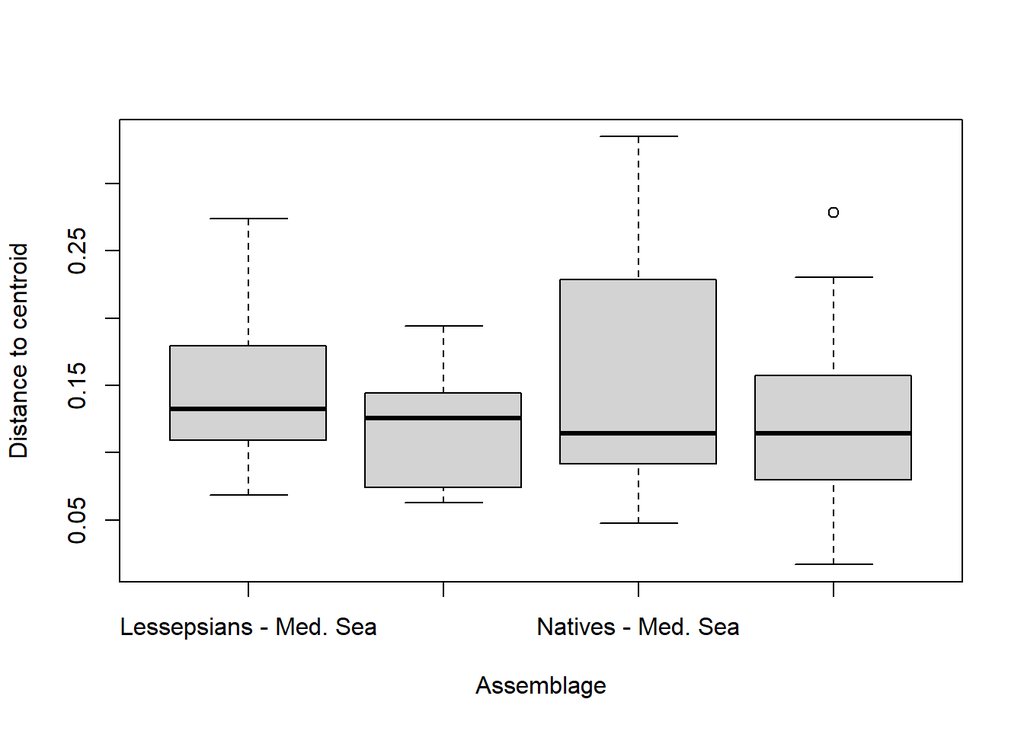

```r
write.csv(pairwise_res,"./models/pairwise_permanova__res.csv",row.names = F)
# 1. Visualize the Niche Breadth (Distance to Centroid)
# This boxplot will show  who has the "biggest" niche
boxplot(disp_test, xlab = "Assemblage", ylab = "Distance to centroid")
```

#4) Area overlaps Calculate overlaps and area relationships

```r
library(sf)
```

```r
# --- 1. DATA PREPARATION ---
hull_data <- pcoa_df %>%
  ungroup() %>%
  mutate(group_factor = factor(group,
                               levels = c("Natives - Red Sea",
                                          "Lessepsians - Red Sea",
                                          "Lessepsians - Med. Sea",
                                          "Natives - Med. Sea")))

# --- 2. GENERATE HULLS (The Base R Way) ---
# We use chull() to find points and store them in a standard dataframe
hulls_df <- data.frame()

for(g in levels(hull_data$group_factor)) {
  sub_dat <- hull_data %>% filter(group_factor == g)

  # Calculate hull indices
  if(nrow(sub_dat) >= 3) {
    hull_idx <- chull(sub_dat$PCoA1, sub_dat$PCoA2)

    # Extract points and close the loop (first point = last point)
    hull_pts <- sub_dat[c(hull_idx, hull_idx[1]), ]

    # Add to master dataframe
    hulls_df <- rbind(hulls_df, hull_pts)
  }
}

# --- 3. BACKGROUND STATS (Using SF for intersection math only) ---
overlap_results <- data.frame()
# Helper to make SF polygon from points
make_poly <- function(df) {
  mat <- as.matrix(df[, c("PCoA1", "PCoA2")])
  st_polygon(list(mat)) %>% st_sfc() %>% st_as_sf()
}

# Loop for overlaps (Background calc)
groups <- levels(hull_data$group_factor)
pairs <- combn(groups, 2, simplify = FALSE)

for(p in pairs) {
  g1 <- p[1]; g2 <- p[2]
  df1 <- hulls_df %>% filter(group_factor == g1)
  df2 <- hulls_df %>% filter(group_factor == g2)

  if(nrow(df1) > 0 && nrow(df2) > 0) {
    poly1 <- make_poly(df1); poly2 <- make_poly(df2)
    a1 <- st_area(poly1); a2 <- st_area(poly2)
    inter <- st_intersection(poly1, poly2)
    a_shared <- if(length(inter) > 0) st_area(inter) else 0

    overlap_results <- rbind(overlap_results, data.frame(
      Group_A = g1, Group_B = g2,
      Overlap_Pct_of_A = round(as.numeric(a_shared/a1)*100, 1),
      Overlap_Pct_of_B = round(as.numeric(a_shared/a2)*100, 1)
    ))
  }
}

print(overlap_results) # stats table
```

```
##                  Group_A                Group_B Overlap_Pct_of_A
## 1      Natives - Red Sea  Lessepsians - Red Sea             26.7
## 2      Natives - Red Sea Lessepsians - Med. Sea              5.2
## 3      Natives - Red Sea     Natives - Med. Sea              9.8
## 4  Lessepsians - Red Sea Lessepsians - Med. Sea              2.4
## 5  Lessepsians - Red Sea     Natives - Med. Sea             17.6
## 6 Lessepsians - Med. Sea     Natives - Med. Sea             87.6
##   Overlap_Pct_of_B
## 1             96.7
## 2              6.8
## 3              8.4
## 4              0.9
## 5              4.2
## 6             56.8
```

```r
# --- 4. CENTROIDS ---
centroids_all <- hull_data %>%
  group_by(group_factor) %>%
  summarise(PCoA1 = mean(PCoA1), PCoA2 = mean(PCoA2), .groups = "drop")
centroids_all
```

```
## # A tibble: 4 × 3
##   group_factor              PCoA1    PCoA2
##   <fct>                     <dbl>    <dbl>
## 1 Natives - Red Sea      -0.0647   0.00388
## 2 Lessepsians - Red Sea  -0.00504  0.0727
## 3 Lessepsians - Med. Sea  0.138    0.00182
## 4 Natives - Med. Sea      0.131   -0.0518
```

#5) Plot assemblages

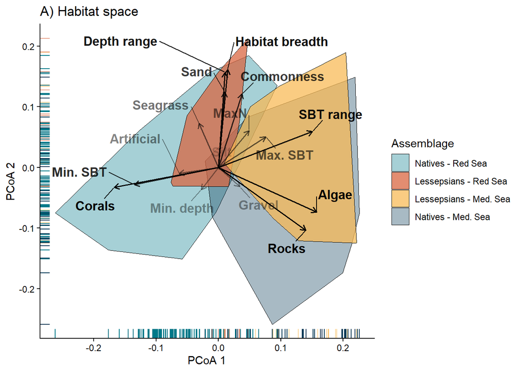

```r
# --- 1. SETUP COLORS ---
custom_colors <- c("Natives - Red Sea" = "#007989",
                   "Lessepsians - Red Sea"     = "#D9643E",
                   "Natives - Med. Sea" = "#073956",
                   "Lessepsians - Med. Sea"     = "#F8B954")

# --- 2. SPLIT DATA INTO LAYERS ---
# Instead of sorting, we just create two separate dataframes.
# This forces ggplot to draw them in the order we write the code.

# Background Layer (Natives)
hulls_natives <- hulls_df %>% filter(grepl("Natives", group_factor))
points_natives <- hull_data %>% filter(grepl("Natives", group_factor))

# Foreground Layer (NIS - Invaders)
hulls_nis <- hulls_df %>% filter(grepl("Lessepsians", group_factor))
points_nis <- hull_data %>% filter(grepl("Lessepsians", group_factor))

# --- 3. RECALCULATE ARROWS ---
trait_loadings <- envfit(pcoa_res$vectors[,1:2], traits, permutations = 999)
arrow_df <- as.data.frame(scores(trait_loadings, display = "vectors")) * 0.2
arrow_df$trait <- rownames(arrow_df)
arrow_df <- arrow_df %>%
  mutate(vector_len = sqrt(Axis.1^2 + Axis.2^2))

# --- 4. THE PLOT (TWO LAYERS) ---
plot_hulls_all <- ggplot() +

  # LAYER 1: Natives Polygons (Bottom)
  geom_polygon(data = hulls_natives,
               aes(x = PCoA1, y = PCoA2, fill = group_factor),
               alpha = 0.35, color = "black", size = 0.2) +

  # LAYER 2: NIS Polygons (Top - Guaranteed)
  geom_polygon(data = hulls_nis,
               aes(x = PCoA1, y = PCoA2, fill = group_factor),
               alpha = 0.735, color = "black", size = 0.2) +


  # LAYER 6: NIS Points (Top Points)
  geom_rug(
    data = points_nis,
    aes(x = PCoA1, y = PCoA2, color = group_factor),
    #size = 1.5,
    alpha = 0.6,
    #shape = 21,
    #color = "black",
    show.legend = F
  ) +

  # LAYER 5: Natives Points (Bottom Points)
  geom_rug(
    data = points_natives,
    aes(x = PCoA1, y = PCoA2, color = group_factor),
    #size = 1.5,
   # alpha = 0.6,
    #shape = 21,
    #color = "black",
    show.legend = F
  ) +

  # LAYER 3: Arrows
  geom_segment(data = arrow_df,
               aes(x = 0, y = 0, xend = Axis.1, yend = Axis.2, alpha = vector_len),
               arrow = arrow(length = unit(0.2, "cm")), color = "black", size=0.6) +

  # LAYER 4: Trait Labels
  geom_text_repel(data = arrow_df,
                  aes(x = Axis.1, y = Axis.2, label = trait, alpha = vector_len),
                  color = "black", fontface = "bold", size = 4.4,
                  box.padding = 0.8,
                  min.segment.length = 0
                  #bg.color="white",
                  #bg.r=0.08
                  ) +
  # Scales & Legend
  scale_fill_manual(
    name = "Assemblage",
    values = custom_colors,
    # THIS CONTROLS THE LEGEND ORDER:
    breaks = c("Natives - Red Sea", "Lessepsians - Red Sea", "Lessepsians - Med. Sea", "Natives - Med. Sea")
  ) +
  scale_color_manual(
    name = "Assemblage",
    values = custom_colors,
    # THIS CONTROLS THE LEGEND ORDER:
    breaks = c("Natives - Red Sea", "Lessepsians - Red Sea", "Lessepsians - Med. Sea", "Natives - Med. Sea")
  )+
  scale_alpha_continuous(range = c(0.2, 1), guide = "none") +
  theme_classic() +
  labs(
    x = "PCoA 1",
    y = "PCoA 2",
    title = "A) Habitat space"#,
    # caption = paste0(
    #   "Native range comp.: P = 0.0001; ",
    #   "Native-invaded range comp.: P = 0.0001; ",
    #   "Invaded range comp.: P = 0.284"
  #  )
  )
print(plot_hulls_all)
```

#6) Shared assembalge ##6.1) Identify species present in BOTH seas

```r
shared_species_list <-  sp_level_data %>%
  group_by(species) %>%
  filter(n_distinct(sea) == 2) %>% # Must have exactly 2 sea entries
  pull(species) %>%
  unique()
```

##6.2) Extract PCoA Coordinates for these species from the Global PCoA We use the Global Space so the axes (PCoA1, PCoA2) mean the same thing for both groups

```r
rs_coords <- pcoa_df %>%
  filter(species %in% shared_species_list, sea == "red") %>%
  arrange(species) %>% # Sort alphabetically to ensure alignment
  select(species, PCoA1, PCoA2) %>%
  remove_rownames() %>%
  column_to_rownames("species")

med_coords <- pcoa_df %>%
  filter(species %in% shared_species_list, sea == "med") %>%
  arrange(species) %>% # Sort alphabetically to match RS
  select(species, PCoA1, PCoA2) %>%
    remove_rownames() %>%
  column_to_rownames("species")

#Validation check
if(!identical(rownames(rs_coords), rownames(med_coords))) {
  stop("Error: Row names do not match! Check sorting.")
} else {
  print("Data aligned correctly. Ready for Procrustes.")
}
```

```
## [1] "Data aligned correctly. Ready for Procrustes."
```

##6.3) Run Procrustes Analysis & Permutation Test This step rotates the Red Sea configuration to best fit the Mediterranean configuration. The residuals represent the shift distance.

```r
# 1. Run Procrustes Analysis
# symmetric = TRUE calculates the fit without assuming one configuration is fixed
proc_res <- procrustes(X = rs_coords, Y = med_coords, symmetric = TRUE)

# 2. Test Significance (PROTEST)
# Tests if the similarity between RS and Med niches is greater than random
protest_res <- protest(X = rs_coords, Y = med_coords, permutations = 9999)

# Print Global Results
print(protest_res)
```

```
##
## Call:
## protest(X = rs_coords, Y = med_coords, permutations = 9999)
##
## Procrustes Sum of Squares (m12 squared):        0.9312
## Correlation in a symmetric Procrustes rotation: 0.2622
## Significance:  0.7138
##
## Permutation: free
## Number of permutations: 9999
```